# Анализ рынка венчурных инвестиций

Рынок венчурных инвестиций представляет собой сегмент финансового рынка, где осуществляются инвестиции в стартапы и перспективные компании. Стартапы — это молодые, небольшие, быстроразвивающиеся компании, в основе которых лежит новая уникальная технология или бизнес-идея и которые стремятся создать инновационный продукт или услугу. Такие компании работают в условиях неопределённости и риска, и вместе с тем, могут иметь значительный потенциал роста и доходности. Поскольку стартапы имеют маленький стартовый капитал и обычно находятся в фазе становления, они не могут рассчитывать на традиционные формы финансирования, как например, публичное размещение акций на бирже. В то же время, стартапы ориентированы на быстрый рост, поэтому стремятся привлечь инвестиции для финансирования своей деятельности и развития.

Венчурные инвестиции стали популярным инструментом для инвестирования в компании-стартапы. Они направлены на поддержку и финансирование новых компаний на различных стадиях их развития: от зарождения и исследований до масштабирования и выхода на рынок. Венчурные инвестиции предоставляются внешними вкладчиками в обмен на долю в компании или приобретение конвертируемых ценных бумаг (например, конвертируемых облигаций или привилегированных акций).

Инвестирование осуществляется фондами венчурного капитала, корпорациями или отдельными физическими лицами, известными как «бизнес-ангелы». Инвесторы предоставляют компаниям-стартапам не только финансирование, но также свои знания, опыт и связи. Целью венчурных инвесторов является получение высокой прибыли в случае успешного развития и выхода компании на биржу или приобретения компании другим инвестором.

С появлением успешных инвестиций венчурные фонды стали привлекать все больше интереса, и этот класс активов стал значительным в инвестиционной индустрии. Венчурный фонд — это инвестиционный фонд, который собирает деньги от инвесторов и используют их для финансирования стартапов и молодых компаний. Инвесторами в венчурные фонды могут быть как физические лица, так и компании, институциональные инвесторы или государственные организации. Венчурные фонды могут вкладывать деньги в компании на начальном этапе их создания и затем развивать их в течение нескольких лет.

Финансирование стартапов осуществляется посредством инвестиционных раундов. Инвестиционные раунды — это стадии финансирования, на которых стартапы привлекают инвестиции от внешних инвесторов. Раунды инвестиций позволяют минимизировать риски и оценить промежуточные результаты компании. Разбиение на раунды помогает стартапам правильно выбирать инвестиционную стратегию и привлекать на каждый раунд нужного инвестора. На ранних стадиях развития компании инвестиционные раунды обычно называются pre-seed (предпосевной), seed (посевной) и раунд A. На более поздних стадиях могут следовать раунды В, С, D и т. д., в зависимости от потребностей компании и инвесторов. Каждый новый раунд обычно сопровождается новыми условиями инвестиций, оценкой компании и вовлечением новых инвесторов. В случае привлечения бизнес-ангела раунд будет называться ангельским, в случае привлечения капитала венчурного фонда — венчурным. Венчурное инвестирование заканчивается с первым публичным размещением компании своих акций на бирже — выходом на IPO (Initial Public Offering).

Из-за высокой степени неопределённости не все стартапы и молодые компании могут привлечь для своего развития венчурные инвестиции. А с другой стороны, поскольку не все стартапы достигают успеха, для инвестора существует высокий риск потерять вложенных средств. Однако при успешном развитии компании инвесторы смогут получить значительную прибыль, и поэтому этот класс активов привлекает инвесторов, заинтересованных в потенциально крупных выплатах.

Анализ рынка венчурных инвестиций является важным этапом для принятия обоснованных решений о вложении средств в стартапы. Он позволяет определить, инвестирование в какие компании потенциально имеет наименьший риск и может принести высокий доход.

В нашем распоряжении находится база данных, которая хранит информацию о венчурных фондах и инвестициях в компании-стартапы. База данных основана на наборе данных [Startup Investments](https://www.kaggle.com/datasets/justinas/startup-investments).

База данных состоит из 7 таблиц, которые связаны между собой с помощью идентификаторов. В таблицах содержится информация о компаниях-стартапах, сотрудниках компаний и уровне их образования, информация о венчурных фондах, их инвестициях в стартапы, раундах инвестиций, а также сведения о покупках компаний.

**Цель работы:** проанализировать данные о стартапах, венчурных фондах и инвестициях.

**Задачи проекта:** путём написания запросов к базе данных выполнить указания технического задания.

# Содержание

## Описание базы данных

### ER-диаграмма базы данных

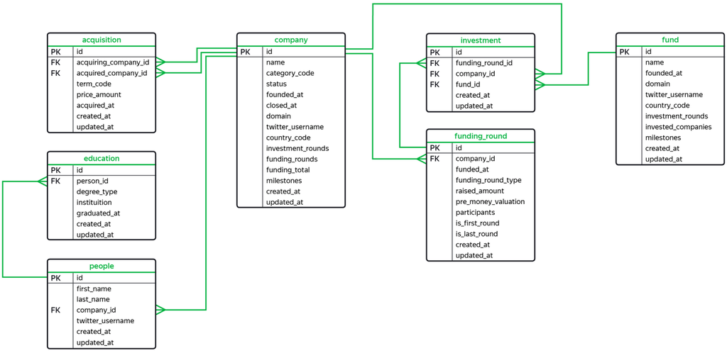

### Описания таблиц базы данных

*Таблица 1*. Описание полей таблицы, содержащей информацию о покупках одних компаний другими.

| `acquisition` |  |  |
| --- | --- | --- |
| Первичный ключ | **id** | идентификатор (уникальный номер) покупки |
| Внешний ключ | **acquiring_company_id** | идентификатор компании, которая покупает другую компанию [ссылается на таблицу **`company`**] |
| Внешний ключ | **acquired_company_id** | идентификатор компании, которую покупают [ссылается на таблицу **`company`**] |
|  | **term_code** | способ оплаты сделки: - **cash** — наличными; - **stock** — акциями компании; - **cash_and_stock** — смешанный тип оплаты: наличными и акциями компании |
|  | **price_amount** | сумма покупки в долларах |
|  | **acquired_at** | дата совершения сделки |
|  | **created_at** | дата и время создания записи в таблице |
|  | **updated_at** | дата и время обновления записи в таблице |

*Таблица 2*. Описание полей таблицы, содержащей информацию о компаниях-стартапах.

| `company` |  |  |
| --- | --- | --- |
| Первичный ключ | **id** | идентификатор (уникальный номер) компании |
|  | **name** | название компании |
|  | **category_code** | категория деятельности компании, например: - **news** — специализируется на работе с новостями; - **social** — специализируется на социальной работе |
|  | **status** | статус компании: - **acquired** — приобретена; - **operating** — действует; - **ipo** — вышла на IPO; - **closed** — перестала существовать |
|  | **founded_at** | дата основания компании |
|  | **closed_at** | дата закрытия компании (указывается, если компания больше не существует) |
|  | **domain** | домен сайта компании |
|  | **twitter_username** | название профиля компании в твиттере |
|  | **country_code** | код страны, например: - **USA** — США; - **GBR** — Великобритания |
|  | **investment_rounds** | число раундов, в которых компания участвовала как инвестор |
|  | **funding_rounds** | число раундов, в которых компания привлекала инвестиции |
|  | **funding_total** | сумма привлечённых инвестиций в долларах |
|  | **milestones** | количество важных этапов в истории компании |
|  | **created_at** | дата и время создания записи в таблице |
|  | **updated_at** | дата и время обновления записи в таблице |

*Таблица 3*. Описание полей таблицы, содержащей информацию об уровне образования сотрудников компаний.

| `education` |  |  |
| --- | --- | --- |
| Первичный ключ | **id** | уникальный номер записи с информацией об образовании |
| Внешний ключ | **person_id** | идентификатор человека, информация о котором представлена в записи [ссылается на таблицу **`people`**] |
|  | **degree_type** | учебная степень, например: - **BA** — Bachelor of Arts — бакалавр гуманитарных наук; - **MS** — Master of Science — магистр естественных наук |
|  | **instituition** | учебное заведение, название университета |
|  | **graduated_at** | дата завершения обучения, выпуска |
|  | **created_at** | дата и время создания записи в таблице |
|  | **updated_at** | дата и время обновления записи в таблице |

*Таблица 4*. Описание полей таблицы, содержащей информацию о венчурных фондах.

| `fund` |  |  |
| --- | --- | --- |
| Первичный ключ | **id** | уникальный номер венчурного фонда |
|  | **name** | название венчурного фонда |
|  | **founded_at** | дата основания фонда |
|  | **domain** | домен сайта фонда |
|  | **twitter_username** | профиль фонда в твиттере |
|  | **country_code** | код страны фонда |
|  | **investment_rounds** | число инвестиционных раундов, в которых фонд принимал участие |
|  | **invested_companies** | число компаний, в которые инвестировал фонд |
|  | **milestones** | количество важных этапов в истории фонда |
|  | **created_at** | дата и время создания записи в таблице |
|  | **updated_at** | дата и время обновления записи в таблице |

*Таблица 5*. Описание полей таблицы, содержащей информацию о раундах инвестиций.

| `funding_round` |  |  |
| --- | --- | --- |
| Первичный ключ | **id** | уникальный номер инвестиционного раунда |
| Внешний ключ | **company_id** | уникальный номер компании, участвовавшей в инвестиционном раунде [ссылается на таблицу **`company`**] |
|  | **funded_at** | дата проведения раунда |
|  | **funding_round_type** | тип инвестиционного раунда, например: - **venture** — венчурный раунд; - **angel** — ангельский раунд; - **series_a** — раунд А |
|  | **raised_amount** | сумма инвестиций, которую привлекла компания в этом раунде в долларах |
|  | **pre_money_valuation** | предварительная, проведённая до инвестиций оценка стоимости компании в долларах |
|  | **participants** | количество участников инвестиционного раунда |
|  | **is_first_round** | является ли этот раунд первым для компании |
|  | **is_last_round** | является ли этот раунд последним для компании |
|  | **created_at** | дата и время создания записи в таблице |
|  | **updated_at** | дата и время обновления записи в таблице |

*Таблица 6*. Описание полей таблицы, содержащей информацию об инвестициях венчурных фондов в компании-стартапы.

| `investment` |  |  |
| --- | --- | --- |
| Первичный ключ | **id** | уникальный номер инвестиции |
| Внешний ключ | **funding_round_id** | уникальный номер раунда инвестиции [ссылается на таблицу **`funding_round`**] |
| Внешний ключ | **company_id** | уникальный номер компании-стартапа, в которую инвестируют [ссылается на таблицу **`company`**] |
| Внешний ключ | **fund_id** | уникальный номер фонда, инвестирующего в компанию-стартап [ссылается на таблицу **`fund`**] |
|  | **created_at** | дата и время создания записи в таблице |
|  | **updated_at** | дата и время обновления записи в таблице |

*Таблица 7*. Описание полей таблицы, содержащей информацию о сотрудниках компаний-стартапов.

| `people` |  |  |
| --- | --- | --- |
| Первичный ключ | **id** | уникальный номер сотрудника |
|  | **first_name** | имя сотрудника |
|  | **last_name** | фамилия сотрудника |
| Внешний ключ | **company_id** | уникальный номер компании-стартапа [ссылается на таблицу **`company`**] |
|  | **twitter_username** | профиль сотрудника в твиттере |
|  | **created_at** | дата и время создания записи в таблице |
|  | **updated_at** | дата и время обновления записи в таблице |

## Запросы к базе данных

Путём написания запросов к базе данных на языке PostgreSQL выполнялось агрегирование и сведение информации в таблицы, проводились необходимые расчёты.

Выполнение запросов к базе данных производилось в специальном тренажёре. Поэтому ниже представлены только тексты запросов и результаты их выполнения.

1. Определить, какое количество компаний закрылось.

```
select count(id)
  from company
 where status = 'closed';
```

| count |
| --- |
| 2584 |

**Вывод:** в базе данных содержится информация о 2584 стартапах, которые уже закрылись.

2. Отобразить количество привлечённых средств для новостных компаний США.

Использовать данные из таблицы `company`.  
Отсортировать таблицу по убыванию значений в поле `funding_total`.

```
select sum(funding_total)
  from company
 where category_code = 'news'
   and country_code = 'USA'
 group by id
 order by funding_total desc;
```

| sum |
| --- |
| 6.22553e+08 |
| 2.5e+08 |
| 1.605e+08 |
| 1.28e+08 |
| 1.265e+08 |
| ... |
| 0 |
| 0 |
| 0 |
| 0 |
| 0 |

**Вывод:** не для всех новостных компаний из США удалось привлечь средства. Максимальное количество привлечённых для одной компании средств составило $$$ 623 млн.

3. Найти общую сумму сделок по покупке одних компаний другими в долларах.

Отобрать сделки, которые осуществлялись только за наличные с 2011 по 2013 год включительно.

```
select sum(price_amount)
  from acquisition
 where term_code = 'cash'
   and extract(year from acquired_at::timestamp) between 2011 and 2013;
```

| sum |
| --- |
| 1.37762e+11 |

**Вывод:** за период 2011–2013 гг. общая сумма сделок по покупке одних компаний другими, осуществлённых за наличный расчёт, составила $$$ 138 млрд.

4. Отобразить имя, фамилию и названия аккаунтов людей в твиттере, у которых названия аккаунтов начинаются на `'Silver'`.

```
select first_name, last_name, twitter_username
  from people
 where twitter_username like 'Silver%';
```

| first_name | last_name | twitter_username |
| --- | --- | --- |
| Rebecca | Silver | SilverRebecca |
| Silver | Teede | SilverMatrixx |
| Mattias | Guilotte | Silverreven |

**Вывод:** только у 3 человек названия аккаунтов в твиттере начинаются на Silver.

5. Вывести на экран всю информацию о людях, у которых названия аккаунтов в твиттере содержат подстроку `'money'`, а фамилия начинается на `'K'`.

```
select *
  from people
 where twitter_username like '%money%'
   and last_name like 'K%';
```

| id | first_name | last_name | company_id | twitter_username | created_at | updated_at |
| --- | --- | --- | --- | --- | --- | --- |
| 63081 | Gregory | Kim |  | gmoney75 | 2010-07-13 03:46:28 | 2011-12-12 22:01:34 |

**Вывод:** только у одного человека название аккаунта в триттере содержит подстроку money, а фамилия начинается на K — это Gregory Kim.

6. Отобразить для каждой страны общую сумму привлечённых инвестиций, которые получили компании, зарегистрированные в этой стране. Страну, в которой зарегистрирована компания, можно определить по коду страны.

Отсортировать данные по убыванию суммы.

```
select country_code, sum(funding_total)
  from company
 group by country_code
 order by sum(funding_total) desc;
```

| country_code | sum |
| --- | --- |
| USA | 3.10588e+11 |
| GBR | 1.77056e+10 |
|  | 1.08559e+10 |
| CHN | 1.06897e+10 |
| CAN | 9.86636e+09 |
| ... | ... |
| TZA | 0 |
| VCT | 0 |
| VIR | 0 |
| YEM | 0 |
| ZWE | 0 |

**Вывод:** не во всех странах существуют компании, для которых удалось привлечь инвестиции. Максимальная сумма инвестиций — $$$ 311 млрд — привлечено для компаний, зарегистрированных в США.

На втором месте — Великобритания, сумма привлечённых инвестиций составила $$$ 18 млрд, что на порядок ниже, чем для компаний из США.

На третьем месте — Китай, сумма привлечённых инвестиций составила $$$ 11 млрд.

Почти такую же сумму инвестиций — почти $$$ 11 млрд — имеют компании, для которых неизвестна страна регистрации.

7. Составить таблицу, в которую войдёт дата проведения раунда, а также минимальное и максимальное значения суммы инвестиций, привлечённых в эту дату.

Оставить в итоговой таблице только те записи, в которых минимальное значение суммы инвестиций не равно нулю и не равно максимальному значению.

```
select funded_at, min(raised_amount), max(raised_amount)
  from funding_round
 group by funded_at
having min(raised_amount) > 0
   and min(raised_amount) != max(raised_amount);
```

| funded_at | min | max |
| --- | --- | --- |
| 2012-08-22 | 40000 | 7.5e+07 |
| 2010-07-25 | 3.27825e+06 | 9e+06 |
| 2002-03-01 | 2.84418e+06 | 8.95915e+06 |
| 2010-10-11 | 28000 | 2e+08 |
| 2007-01-18 | 5.5e+06 | 2.3e+07 |
| ... | ... | ... |
| 2008-03-17 | 1e+06 | 7.2e+07 |
| 2008-03-28 | 1.1e+06 | 2.03e+07 |
| 1999-06-01 | 250000 | 6e+06 |
| 2010-08-06 | 291 | 1.45e+07 |
| 2005-09-23 | 4e+06 | 5e+06 |

**Вывод:** были такие дни, в которые сумма привлечённых инвестиций могла изменяться на несколько порядков: от $\$$ 100 до $$$ 10 млн, и такие дни, в которые суммы привлечённых инвестиций оставались одного порядка, например, $$$ 1 млн.

8. Создать поле с категориями:
   - `high_activity` — для фондов, которые инвестируют в 100 и более компаний,
   - `middle_activity` — для фондов, которые инвестируют в 20 и более компаний до 100,
   - `low_activity` — если количество инвестируемых компаний фонда не достигает 20.

Отобразить все поля таблицы `fund` и новое поле с категориями.

```
select *,
       case when invested_companies >= 100 then 'high_activity'
            when invested_companies >= 20 then 'middle_activity'
            else 'low_activity'
        end as activity
  from fund;
```

| id | name | founded_at | domain | twitter_username | country_code | investment_rounds | invested_companies | milestones | created_at | updated_at | activity |
| --- | --- | --- | --- | --- | --- | --- | --- | --- | --- | --- | --- |
| 13131 |  |  |  |  |  | 0 | 0 | 0 | 2013-08-19 18:46:55 | 2013-08-19 19:55:07 | low_activity |
| 1 | Greylock Partners | 1965-01-01 | greylock.com | greylockvc | USA | 307 | 196 | 0 | 2007-05-25 20:18:23 | 2012-12-27 00:42:24 | high_activity |
| 10 | Mission Ventures | 1996-01-01 | missionventures.com |  | USA | 58 | 33 | 0 | 2007-06-05 05:24:58 | 2013-10-10 22:06:31 | middle_activity |
| 100 | Kapor Enterprises, Inc. |  | kei.com |  | USA | 2 | 1 | 0 | 2007-07-12 09:42:21 | 2008-11-21 05:41:53 | low_activity |
| 1000 | Speed Ventures |  |  |  |  | 0 | 0 | 1 | 2008-04-13 23:52:27 | 2008-12-10 09:37:18 | low_activity |
| ... | ... | ... | ... | ... | ... | ... | ... | ... | ... | ... | ... |

**Вывод:** благодаря наличию фондов, которые инвестируют в различное количество компаний, возможно ввести новый признак и разделить все фонды на три категории так, что количества 20 и 100 компаний являются граничными.

9. Посчитать для каждой из категорий, назначенных в предыдущем задании, округлённое до ближайшего целого числа среднее количество инвестиционных раундов, в которых фонд принимал участие.

Вывести на экран категории и среднее число инвестиционных раундов.  
Отсортировать таблицу по возрастанию среднего.

```
with activ_t as (

    select *,
           case when invested_companies >= 100 then 'high_activity'
                when invested_companies >= 20 then 'middle_activity'
                else 'low_activity'
            end as activity
       from fund)

select activity, round(avg(investment_rounds)) as round_count
  from activ_t
 group by activity
 order by round_count;
```

| activity | round_count |
| --- | --- |
| low_activity | 2 |
| middle_activity | 51 |
| high_activity | 252 |

**Вывод:** фонды, которые инвестирую в 100 и более компаний в среднем участвуют в 252 инвестиционных раундах. Фонды, которые инвестируют в не менее чем 20 фондов (но менее 100), в среднем участвуют в 51 инвестиционном раунде. И только в 2 инвестиционных раундах (в среднем) участвуют фонды, инвестирующие в менее чем 20 компаний.

10. Проанализировать, в каких странах находятся фонды, которые чаще всего инвестируют в стартапы.

Посчитать для каждой страны минимальное, максимальное и среднее число компаний, в которые инвестировали фонды этой страны, основанные с 2010 по 2012 год включительно.  
Исключить страны с фондами, у которых минимальное число компаний, получивших инвестиции, равно нулю.  
Выгрузить десять самых активных стран-инвесторов:  
отсортировать таблицу по среднему количеству компаний от большего к меньшему,  
затем добавить сортировку по коду страны в лексикографическом порядке.

```
select country_code,
       min(invested_companies),
       max(invested_companies),
       avg(invested_companies)
  from fund
 where extract(year from founded_at::timestamp) between 2010 and 2012
 group by country_code
having min(invested_companies) != 0
 order by avg(invested_companies) desc, country_code
 limit 10;
```

| country_code | min | max | avg |
| --- | --- | --- | --- |
| BGR | 25 | 35 | 30 |
| CHL | 29 | 29 | 29 |
| UKR | 8 | 10 | 9 |
| LTU | 5 | 5 | 5 |
| IRL | 4 | 5 | 4.5 |
| KEN | 3 | 3 | 3 |
| LBN | 3 | 3 | 3 |
| MUS | 3 | 3 | 3 |
| JPN | 1 | 6 | 2.83333 |
| HKG | 2 | 3 | 2.66667 |

**Вывод:** фонды, основанные с 2010 по 2012 гг. и расположенные в Болгарии, инвестировали в среднем в большее количество компаний. Среднее количество проинвестированных болгарскими фондами компаний — 30. Почти такое же количество компаний — 29 — проинвестировали фонды, основанные в период 2010–2012 гг. и расположенные в Чили. Далее со значительным отрывом находятся фонды из Украины, основанные в тот же период. Среднее количество проинвестированных этими фондами компаний составляет 9.

11. Отобразить имя и фамилию всех сотрудников стартапов.

Добавить поле с названием учебного заведения, которое окончил сотрудник, если эта информация известна.

```
select people.first_name,
       people.last_name,
       education.instituition
  from people
  left join education
         on people.id = education.person_id;
```

| first_name | last_name | instituition |
| --- | --- | --- |
| John | Green | Washington University, St. Louis |
| John | Green | Boston University |
| David | Peters | Rice University |
| Dan | Birdwhistell | University of Cambridge |
| Gal | Cohen | Tel Aviv University |
| ... | ... | ... |
| Jamie | Duklas | University of Denver |
| Jamie | Duklas | University of Wisconsin-Madison |
| Norm | Page | Boston College |
| Eric | Kennedy | Yale University |
| Iqram | Magdon-Ismail | U Penn |

**Вывод:** благодаря наличию сведений об образовании стало возможным составить таблицу, содержащую сведения о фамилии и имени сотрудников и об учебном заведении, которое они окончили.

12. Найти для каждой компании количество учебных заведений, которые окончили её сотрудники.

Вывести название компании и число уникальных названий учебных заведений.  
Составить топ-5 компаний по количеству университетов.

```
select company.name, count(distinct education.instituition)
  from company
 inner join people
         on company.id = people.company_id
  left join education
         on people.id = education.person_id
 group by company.name
 order by count(distinct education.instituition) desc
 limit 5;
```

| name | count |
| --- | --- |
| Google | 167 |
| Yahoo! | 115 |
| Microsoft | 111 |
| Knight Foundation | 74 |
| Comcast | 66 |

**Вывод:** в компании Google работают сотрудники, которые оканчивали учебные заведения из наиболее широкой палитры — всего 167 различных учебных заведения. За ней идут Yahoo! и Microsoft: количество различных учебных заведений, которые заканчивали их сотрудники, почти одинаковое и составляет 115 и 111, соответственно. Замыкают топ-5 компании Knight Foundation и Comcast. Их сотрудники заканчивали ещё меньшее количество различных учебных заведений — 74 и 66, соответственно.

13. Составить список с уникальными названиями закрытых компаний, для которых первый раунд финансирования оказался последним.

```
select distinct company.name
  from company
  left join funding_round
         on company.id = funding_round.company_id
 where company.status = 'closed'
   and funding_round.is_first_round = 1
   and funding_round.is_last_round = 1;
```

| name |
| --- |
| 10BestThings |
| 11i Solutions |
| 169 ST. |
| 1bib |
| 1Cast |
| ... |

**Вывод:** в наборе данных присутствуют компании, для которых был проведён всего один инвестиционный раунд и которые уже ликвидированы.

14. Составить список уникальных номеров сотрудников, которые работают в компаниях, отобранных в предыдущем задании.

```
select id
  from people
 where company_id in (

     select company.id
       from company
       left join funding_round
              on company.id = funding_round.company_id
      where company.status = 'closed'
        and funding_round.is_first_round = 1
        and funding_round.is_last_round = 1);
```

| id |
| --- |
| 10000 |
| 10053 |
| 102056 |
| 100690 |
| 101946 |
| ... |

**Вывод:** в компаниях, для которых проводился всего один инвестиционный раунд и которые уже ликвидированы, работало значительное количество сотрудников.

15. Составить таблицу, куда войдут уникальные пары с номерами сотрудников из предыдущей задачи и учебным заведением, которое окончил сотрудник.

```
select distinct people.id, education.instituition
  from people
 inner join education
         on people.id = education.person_id
 where company_id in (

     select company.id
       from company
       left join funding_round
              on company.id = funding_round.company_id
     where company.status = 'closed'
       and funding_round.is_first_round = 1
       and funding_round.is_last_round = 1)

 order by people.id;
```

| id | instituition |
| --- | --- |
| 349 | AKI |
| 349 | ArtEZ Hogeschool voor de Kunsten |
| 349 | Rijks Akademie |
| 699 | Imperial College |
| 779 | Harvard University |
| ... | ... |

**Вывод:** не все сотрудники, которые работали в ликвидированных компаниях, для которых был проведён только один инвестиционный раунд, заканчивали учебные заведения, либо такая информация отсутствует. Но среди тех, кто оканчивал учебные заведения, есть такие, кто заканчивал более одного учебного заведения.

16. Посчитать количество учебных заведений для каждого сотрудника из предыдущего задания.

Учесть при подсчёте, что некоторые сотрудники могли окончить одно и то же заведение дважды.

```
with pivot as (

    select people.id as id, education.instituition as inst_num
      from people
     inner join education
             on people.id = education.person_id
     where company_id in (

         select company.id
           from company
           left join funding_round
                  on company.id = funding_round.company_id
          where company.status = 'closed'
            and funding_round.is_first_round = 1
            and funding_round.is_last_round = 1))

select id, count(inst_num)
  from pivot
 group by id;
```

| id | count |
| --- | --- |
| 349 | 3 |
| 699 | 1 |
| 779 | 2 |
| 968 | 1 |
| 972 | 1 |

**Вывод:** некоторые сотрудники, которые работали в ликвидированных компаниях, для которых был проведён только один инвестиционный раунд, получали образование несколько раз, причём могли заканчивать разные учебные заведения, а могли окончить одно и то же заведение несколько раз.

17. Дополнить предыдущий запрос и вывести среднее число учебных заведений (всех, не только уникальных), которые окончили сотрудники разных компаний.

```
with pivot as (

    with pivot as (

        select people.id as id,
               education.instituition as inst_name
          from people
         inner join education
                 on people.id = education.person_id
         where company_id in (

             select company.id
               from company
               left join funding_round
                      on company.id = funding_round.company_id
              where company.status = 'closed'
                and funding_round.is_first_round = 1
                and funding_round.is_last_round = 1))

    select id, count(inst_name) as inst_num
      from pivot
     group by id)

select avg(inst_num)
from pivot;
```

| avg |
| --- |
| 1.41509 |

**Вывод:** в среднем сотрудники ликвидированных компаний, для которых был проведён только один инвестиционный раунд, получали образование не менее одного раза.

18. Вывести среднее число учебных заведений (всех, не только уникальных), которые окончили сотрудники `'Facebook'`.

```
with pivot as (

    with pivot as (

        select people.id as id, education.instituition as inst_name
          from people
         inner join education
                 on people.id = education.person_id
         where company_id in (

             select company.id
               from company
               left join funding_round
                      on company.id = funding_round.company_id
              where company.name = 'Facebook'))

    select id,
           count(inst_name) as inst_num
      from pivot
     group by id)

select avg(inst_num)
  from pivot;
```

| avg |
| --- |
| 1.51111 |

**Вывод:** в среднем сотрудники Facebook получали образование 1–2 раза.

19. Составить таблицу из полей:
    - `name_of_fund` — название фонда;
    - `name_of_company` — название компании;
    - `amount` — сумма инвестиций, которую привлекла компания в раунде.

В таблицу войдут данные о компаниях, в истории которых было больше шести важных этапов, а раунды финансирования проходили с 2012 по 2013 год включительно.

```
select fund.name as name_of_fund,
       company.name as name_of_company,
       funding_round.raised_amount as amount
  from investment
 inner join company
         on company.id = investment.company_id
 inner join fund
         on fund.id = investment.fund_id
 inner join funding_round
         on funding_round.id = investment.funding_round_id
 where company.milestones > 6
   and extract(year from funding_round.funded_at) between 2012 and 2013;
```

| name_of_fund | name_of_company | amount |
| --- | --- | --- |
| SAP Ventures | OpenX | 2.50112e+07 |
| Samsung Ventures | OpenX | 2.50112e+07 |
| Index Ventures | OpenX | 2.50112e+07 |
| Presidio Ventures | OpenX | 2.50112e+07 |
| DAG Ventures | Gigya | 2.5e+07 |
| DAG Ventures | Gigya | 1.53e+07 |
| Accel Partners | OpenX | 2.50112e+07 |
| Benchmark | Gigya | 2.5e+07 |
| Benchmark | Gigya | 1.53e+07 |
| Greenspring Associates | Gigya | 2.5e+07 |
| Mayfield Fund | Gigya | 2.5e+07 |
| Mayfield Fund | Gigya | 1.53e+07 |
| Mitsui Global Investment | OpenX | 2.50112e+07 |
| Advance Publication | Gigya | 1.53e+07 |

20. Выгрузить таблицу, в которой будут такие поля:
    - название компании-покупателя;
    - сумма сделки;
    - название компании, которую купили;
    - сумма инвестиций, вложенных в купленную компанию;
    - доля, которая отображает, во сколько раз сумма покупки превысила сумму вложенных в компанию инвестиций, округлённая до ближайшего целого числа.

Не учитывать те сделки, в которых сумма покупки равна нулю. Если сумма инвестиций в компанию равна нулю, исключить такую компанию из таблицы.  
Отсортировать таблицу по сумме сделки от большей к меньшей, а затем по названию купленной компании в лексикографическом порядке.  
Ограничить таблицу первыми десятью записями.

```
select buyer.name as buyer_name,
       acquisition.price_amount,
       seller.name as seller_name,
       seller.funding_total,
       round(acquisition.price_amount / seller.funding_total) as koef
  from acquisition
 inner join company as seller
         on seller.id = acquisition.acquired_company_id
 inner join company as buyer
         on buyer.id = acquisition.acquiring_company_id
 where acquisition.price_amount != 0
   and seller.funding_total != 0
 order by acquisition.price_amount desc, seller_name
 limit 10;
```

| buyer_name | price_amount | seller_name | funding_total | koef |
| --- | --- | --- | --- | --- |
| Microsoft | 8.5e+09 | Skype | 7.6805e+07 | 111 |
| Scout Labs | 4.9e+09 | Varian Semiconductor Equipment Associates | 4.8e+06 | 1021 |
| Broadcom | 3.7e+09 | Aeluros | 7.97e+06 | 464 |
| Broadcom | 3.7e+09 | NetLogic Microsystems | 1.88527e+08 | 20 |
| Level 3 Communications | 3e+09 | Global Crossing | 4.1e+07 | 73 |
| Yahoo! | 2.87e+09 | GeoCities | 4e+07 | 72 |
| eBay | 2.6e+09 | Skype | 7.6805e+07 | 34 |
| Salesforce | 2.5e+09 | ExactTarget | 2.3821e+08 | 10 |
| Johnson & Johnson | 2.3e+09 | Crucell | 4.43e+08 | 5 |

**Вывод:** наибольшая сумма, которую заплатила одна компания за покупку другой компании, составила $\$$ 8,5 млрд: Microsoft купила Skype. Причём сумма покупки на два порядка (более чем в 100 раз) превысила сумму вложенных в Skype инвестиций. Ещё больше &mdash; в 500 раз &mdash; сумма покупки Aeluros превысила сумму сложенных в неё инвестиций. Её купила Broadcom за $$$ 3,7 млрд. Но ещё больше разница между суммой покупки и суммой вложенных инвестиций у компании Varian Semiconductor Equipment Associates. Её купила Scout Labs за $$$ 4,9 млрд, что в 1000 раз больше суммы вложенных инвестиций.

21. Выгрузить таблицу, в которую войдут названия компаний из категории `'social'`, получившие финансирование с 2010 по 2013 год включительно.

Проверить, что сумма инвестиций не равна нулю.  
Вывести также номер месяца, в котором проходил раунд финансирования.

```
select company.name,
       extract(month from funding_round.funded_at) as month
  from company
 inner join funding_round
         on company.id = funding_round.company_id
 where funding_round.raised_amount != 0
   and company.category_code = 'social'
   and extract(year from funding_round.funded_at) between 2010 and 2013;
```

| name | month |
| --- | --- |
| Klout | 1 |
| WorkSimple | 3 |
| HengZhi | 1 |
| Twitter | 1 |
| SocialGO | 1 |
| ... | ... |
| tymr | 12 |
| Startup Weekend | 11 |
| Mingly | 11 |
| Startup Weekend | 9 |
| Startup Weekend | 9 |

**Вывод:** компании, специализирующиеся на социальной работе, в период с 2010 по 2013 гг. получали финансирование. Раунды финансирования могли проходить в различные месяцы в течение года.

22. Отобрать данные по месяцам с 2010 по 2013 год, когда проходили инвестиционные раунды.

Сгруппировать данные по номеру месяца и получить таблицу, в которой будут поля:

```
- номер месяца, в котором проходили раунды;
- количество уникальных названий фондов из США, которые инвестировали в этом месяце;
- количество компаний, купленных за этот месяц;
- общая сумма сделок по покупкам в этом месяце.
```

```
with usa_funds as (

    select extract(month from funding_round.funded_at) as month,
           count(distinct fund.name) as fund_num
      from investment
     inner join fund
             on fund.id = investment.fund_id
     inner join funding_round
             on funding_round.id = investment.funding_round_id
     where fund.country_code = 'USA'
       and extract(year from funding_round.funded_at) between 2010 and 2013
     group by month),

sales as (

    select extract(month from acquired_at) as month,
           count(acquired_company_id) as company_count,
           sum(price_amount) as total_amount
      from acquisition
     where extract(year from acquired_at) between 2010 and 2013
     group by month)

select usa_funds.month,
       usa_funds.fund_num,
       sales.company_count,
       sales.total_amount
  from usa_funds
  left join sales
         on usa_funds.month = sales.month;
```

| month | fund_num | company_count | total_amount |
| --- | --- | --- | --- |
| 1 | 815 | 600 | 2.71083e+10 |
| 2 | 637 | 418 | 4.13903e+10 |
| 3 | 695 | 458 | 5.95016e+10 |
| 4 | 718 | 411 | 3.03837e+10 |
| 5 | 695 | 532 | 8.60122e+10 |
| 6 | 785 | 525 | 5.20883e+10 |
| 7 | 803 | 488 | 4.98541e+10 |
| 8 | 726 | 454 | 7.77093e+10 |
| 9 | 793 | 491 | 6.97409e+10 |
| 10 | 764 | 473 | 4.85567e+10 |
| 11 | 661 | 414 | 4.79386e+10 |
| 12 | 590 | 433 | 3.74251e+10 |

**Вывод:** в период с 2010 по 2013 гг. январь был тем месяцем, когда покупалось наибольшее число компаний — 600. Причём количество фондов, которые принимали участие в инвестировании, было также максимальным — 815. Однако общая сумма сделок была минимальной и составляла $$$ 27 млрд.

Апрель был месяцем, в который покупалось наименьшее количество компаний — всего 411. Декабрь — месяцем, в который принимало участие в инвестировании наименьшее число фондов — всего 590. А вот май стал месяцем, когда удалось привлечь максимальное число инвестиций — $$$ 86 млрд.

23. Составить сводную таблицу и вывести среднюю сумму инвестиций для стран, в которых есть стартапы, зарегистрированные в 2011, 2012 и 2013 годах.

Данные за каждый год должны быть в отдельном поле.  
Отсортировать таблицу по среднему значению инвестиций за 2011 год от большего к меньшему.

```
with year_2011 as (

    select country_code, avg(funding_total) as year_2011
      from company
     where extract(year from founded_at) = 2011
     group by country_code),

year_2012 as (

    select country_code, avg(funding_total) as year_2012
      from company
     where extract(year from founded_at) = 2012
     group by country_code),

year_2013 as (

    select country_code, avg(funding_total) as year_2013
      from company
     where extract(year from founded_at) = 2013
     group by country_code)

select year_2011.country_code,
       year_2011.year_2011,
       year_2012.year_2012,
       year_2013.year_2013
  from year_2011
 inner join year_2012
         on year_2011.country_code = year_2012.country_code
 inner join year_2013
         on year_2011.country_code = year_2013.country_code
 order by year_2011 desc;
```

| country_code | year_2011 | year_2012 | year_2013 |
| --- | --- | --- | --- |
| PER | 4e+06 | 41000 | 25000 |
| USA | 2.24396e+06 | 1.20671e+06 | 1.09336e+06 |
| HKG | 2.18078e+06 | 226227 | 0 |
| PHL | 1.75e+06 | 4218.75 | 2500 |
| ARE | 1.718e+06 | 197222 | 35333.3 |
| ... | ... | ... | ... |
| CRI | 0 | 0 | 40000 |
| SVN | 0 | 239616 | 0 |
| BHR | 0 | 0 | 20000 |
| UGA | 0 | 0 | 60400 |
| LKA | 0 | 0 | 0 |

**Вывод:** наибольшее число инвестиций — $\$$ 4 млн &mdash; привлекли в 2011 г. компании, зарегистрированные в Перу; в последующие годы суммы инвестиций значительно снизились. А вот компании, зарегистрированные в США, смогли ежегодно привлекать $$$ 1–2 млн. Кроме того, компании, зарегистрированные в некоторых странах, например, на Коста-Рике, в Словении, Бахрейне и Уганде, не каждый год могли привлекать инвестиции. А компании на Шри-Ланке вообще не смогли в этот период привлечь инвестиции.

## Общий вывод

С помощью выполнения запросов к базе данных удалось выполнить указания технического задания и проанализировать информацию о компаниях-стартапах, венчурных фондах и инвестициях.